# DATA605_w15_Multivariable Calculus

David Simbandumwe

# Question 1

Find the equation of the regression line for the given points. Round any final values to the nearest hundredth, if necessary. (5.6,8.8), (6.3,12.4), (7,14.8), (7.7,18.2), (8.4,20.8)

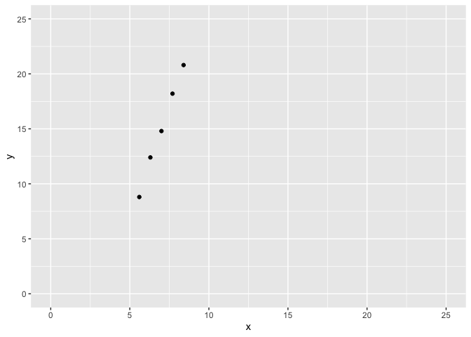

```r
df <- data.frame(
    x = c(5.6,6.3,7,7.7,8.4),
    y = c(8.8,12.4,14.8,18.2,20.8)
)

df %>% ggplot() + geom_point(aes(x=x, y=y)) +
    xlim(0, 25) + ylim(0, 25)
```

```r
lm <- lm(df, formula = y ~ x)
summary(lm)
```

```
##
## Call:
## lm(formula = y ~ x, data = df)
##
## Residuals:
##     1     2     3     4     5
## -0.24  0.38 -0.20  0.22 -0.16
##
## Coefficients:
##             Estimate Std. Error t value Pr(>|t|)
## (Intercept) -14.8000     1.0365  -14.28 0.000744 ***
## x             4.2571     0.1466   29.04 8.97e-05 ***
## ---
## Signif. codes:  0 '***' 0.001 '**' 0.01 '*' 0.05 '.' 0.1 ' ' 1
##
## Residual standard error: 0.3246 on 3 degrees of freedom
## Multiple R-squared:  0.9965, Adjusted R-squared:  0.9953
## F-statistic: 843.1 on 1 and 3 DF,  p-value: 8.971e-05
```

$$y = a + \beta x \\
y = -14.8 + 4.26x$$

# Question 2

2. Find all local maxima, local minima, and saddle points for the function given below. Write your answer(s) in the form ( x, y, z ). Separate multiple points with a comma.

$$f(x,y) = 24x - 6xy^2 - 8y^3 \\$$
- first derivative x
$$dx(x,y) = 6(y^2 - 4) \\
\text{set dx = 0} \\
0 = 6(y^2 - 4) \\
y = +- 2 \\
\text{-------------} \\
f(x,y) = 24x - 6xy^2 - 8y^3 \\
f(2,4) = 24x - 6xy^2 - 8y^3 \\
f(2,2) = -64 \\
(x,y,z) = (2,4,-64 ) \\$$
- second derivative x
$$dx^2(x,y) =
0 \\
(x,y,z) = (4,2,-64 ) \text{ is a sadle point}$$

- first derivative y
  $$dy(x,y) = -12xy + 24y^2 \\
  \text{set dy = 0} \\
  0 = -12xy + 24y^2 \\
  12xy = 24y^2 \\
  x = 2y \\
  \text{set y = +-2} \\
  x = +-4 \\
  \text{-------------} \\
  f(-2,-4) = 24x - 6xy^2 - 8y^3 \\
  f(-2,-4) = 64 \\
  (x,y,z) = (-4,-2,64) \text{ is a sadle point}\\$$
- second derivative y
  $$dy^2(x,y) = -12x + 48y
  \text{set dy = 0} \\
  0 = -12x + 48y \\
  12x = 48y
  x = 2y
  \text{set x = 0} \\
  (x,y,z) = (-4,-2,64 ) \text{ is a sadle point}$$

```r
x <- 4
y <- 2

f = expression(24*x - 6*x*y^2  - 8*y^3)
eval(f)
```

```
## [1] -64
```

```r
x <- -4
y <- -2

f = expression(24*x - 6*x*y^2  - 8*y^3)
eval(f)
```

```
## [1] 64
```

# Question 3

3. A grocery store sells two brands of a product, the “house” brand and a “name” brand. The manager estimates that if she sells the “house” brand for x dollars and the “name” brand for y dollars, she will be able to sell 81 - 21x + 17y units of the “house” brand and 40 + 11x - 23y units of the “name” brand.

Step 1. Find the revenue function R ( x, y ).
$$R(x,y) = -21x^2+81x +28xy - 23y^2 +
40y$$

Step 2. What is the revenue if she sells the “house” brand for $2.30 and the “name” brand for $4.10?

```r
x <- 2.30
y <- 4.10
r <- expression(-21*x^2+81*x +28*x*y - 23*y^2 + 40*y)



print(paste0('total revenue = ', eval(r)))
```

```
## [1] "total revenue = 116.62"
```

# Question 4

4. A company has a plant in Los Angeles and a plant in Denver. The firm is committed to produce a total of 96 units of a product each week. The total weekly cost is given by
   $$C(x, y) =
   \frac{1}{6}x^2 + \frac{1}{6} y^2 + 7x + 25y + 700$$
   , where x is the number of units produced in Los Angeles and y is the number of units produced in Denver. How many units should be produced in each plant to minimize the total weekly cost?

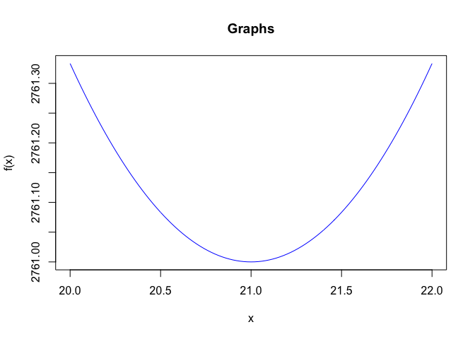

```r
y <- 0:96
f <- function(y){return(1/6*(96-y)^2 + 1/6*y^2 + 7*(96-y) + 25*y +700)}
curve(f, from = 20, to = 22, type="l", main = 'Graphs', col = 'blue')
```

$$C(x, y) = \frac{1}{6}x^2 + \frac{1}{6} y^2 + 7x + 25y + 700 \\
\text{ x = 96 - y} \\
C(x, y) = \frac{1}{6}(96-y)^2 + \frac{1}{6} y^2 + 7x + 25y + 700 \\
Cy(x,y) = \frac{2}{3} (y - 21)
\text{ xCy(x,y) = 0} \\
0 = \frac{2}{3} (y - 21)
y = 21
x = 96 - 21 = 75
C(75,21) = 2761$$

```r
x <- 75
y <- 21
f <- function(x,y){return(1/6*x^2 + 1/6*y^2 + 7*x + 25*y +700)}
print(paste0('4) total cost C(75,21) =  ', f(75,21) ))
```

```
## [1] "4) total cost C(75,21) =  2761"
```

# Question 5

Write your answer in exact form without decimals.
$$\int_{2}^{4}\int_{2}^{4} (e^{8x+3y}) dxdy \\
\text{from wolframalpha} \\
\frac{1}{24}(e^{22}-e^{28}-e^{38}+e^{44})$$